# report

###### a-2-1. weight and displacement(engine displacement)

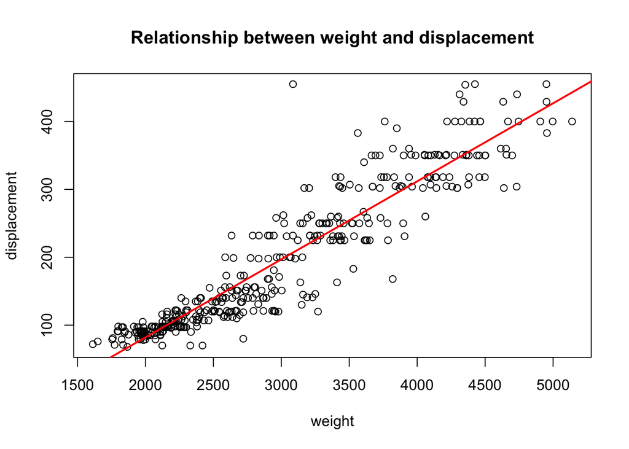

```r
model_3 = lm(Auto$displacement ~ Auto$weight)
plot(Auto$weight, Auto$displacement, xlab="weight", ylab="displacement", main="Relationship between weight and displacement")

abline(model_3,col = "red",lwd = 2)
```

```r
summary(model_3)
```

```
##
## Call:
## lm(formula = Auto$displacement ~ Auto$weight)
##
## Residuals:
##      Min       1Q   Median       3Q      Max
## -123.241  -18.851   -0.316   16.776  248.126
##
## Coefficients:
##               Estimate Std. Error t value Pr(>|t|)
## (Intercept) -1.478e+02  6.951e+00  -21.27   <2e-16 ***
## Auto$weight  1.149e-01  2.245e-03   51.20   <2e-16 ***
## ---
## Signif. codes:  0 '***' 0.001 '**' 0.01 '*' 0.05 '.' 0.1 ' ' 1
##
## Residual standard error: 37.71 on 390 degrees of freedom
## Multiple R-squared:  0.8705, Adjusted R-squared:  0.8701
## F-statistic:  2621 on 1 and 390 DF,  p-value: < 2.2e-16
```

there a statistically significant association between the displacement and weight.
the p-value is less than 0.005.
displacement and weight have a positive correlation.
since R-squared have large value(0.8705), it can be said that this model explains the relationship well.
$$displacement = -147.8 + 0.1149 * weight$$
###### a-2-2. horsepower and acceleration

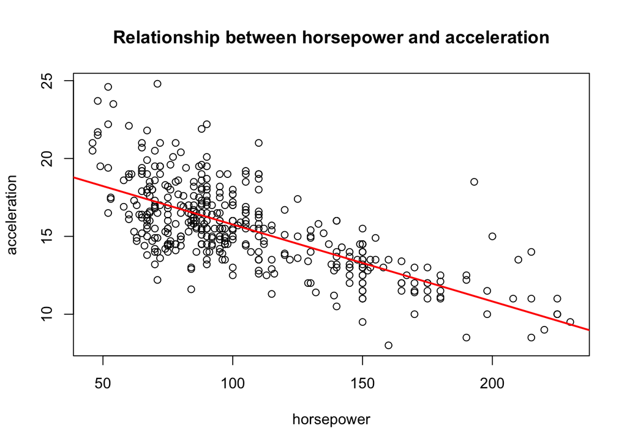

```r
model_4 = lm(Auto$acceleration ~ Auto$horsepower)
plot(Auto$horsepower, Auto$acceleration, xlab="horsepower", ylab="acceleration", main="Relationship between horsepower and acceleration")

abline(model_4,col = "red",lwd = 2)
```

```r
summary(model_4)
```

```
##
## Call:
## lm(formula = Auto$acceleration ~ Auto$horsepower)
##
## Residuals:
##     Min      1Q  Median      3Q     Max
## -4.9947 -1.2913 -0.1748  1.1229  7.6053
##
## Coefficients:
##                 Estimate Std. Error t value Pr(>|t|)
## (Intercept)     20.70193    0.29274   70.72   <2e-16 ***
## Auto$horsepower -0.04940    0.00263  -18.78   <2e-16 ***
## ---
## Signif. codes:  0 '***' 0.001 '**' 0.01 '*' 0.05 '.' 0.1 ' ' 1
##
## Residual standard error: 2.002 on 390 degrees of freedom
## Multiple R-squared:  0.475,  Adjusted R-squared:  0.4736
## F-statistic: 352.8 on 1 and 390 DF,  p-value: < 2.2e-16
```

there a statistically significant association between the horsepower and acceleration.  
the p-value is less than 0.005.  
horsepower and acceleration have a negative correlation.  
R-squared value is 0.475. this model has a moderate level of explanatory power.

##### a-3. Carseats data set

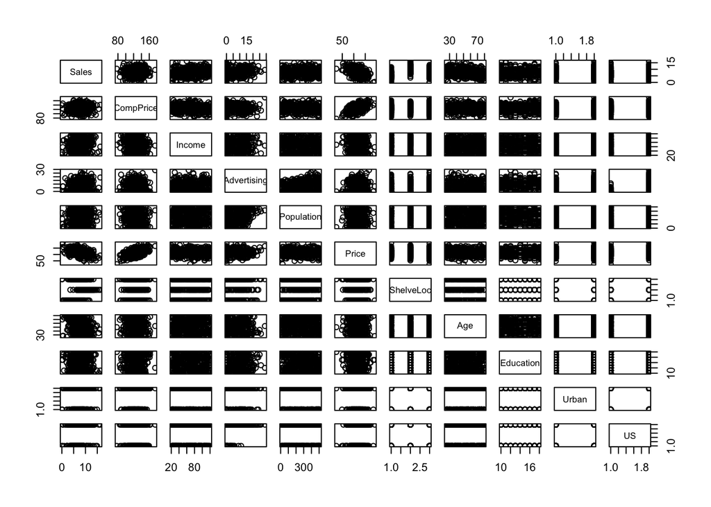

```r
library(ISLR2)
data("Carseats")
pairs(Carseats)
```

###### a-3-1. sales and price

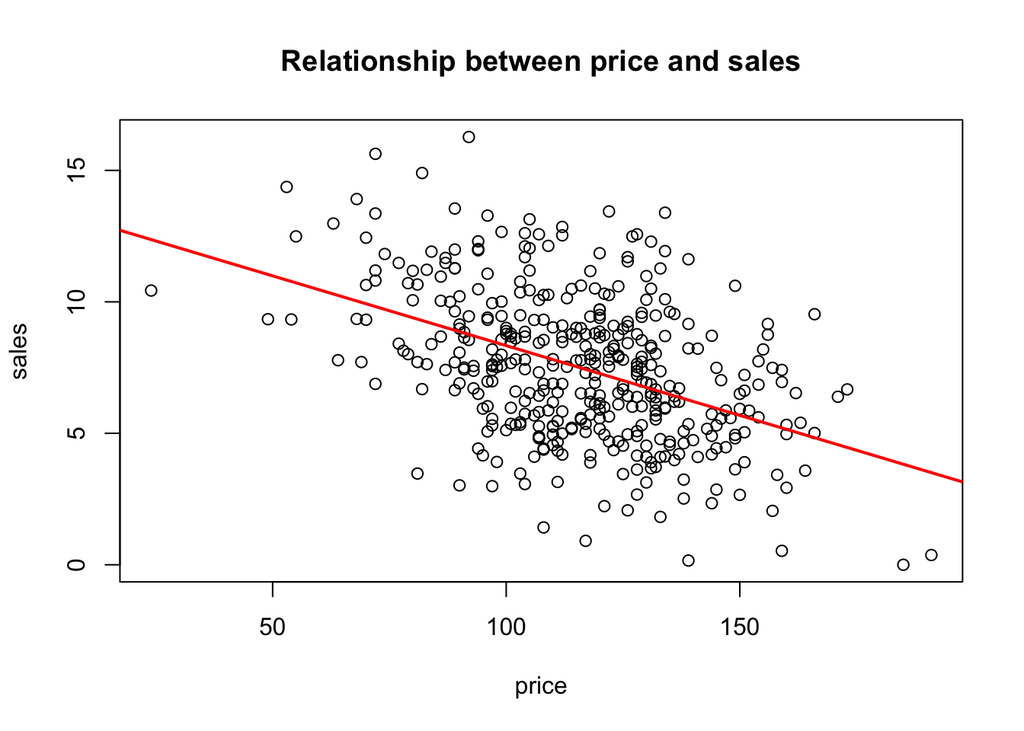

```r
model_5 = lm(Carseats$Sales ~ Carseats$Price)
plot(Carseats$Price, Carseats$Sales, xlab="price", ylab="sales", main="Relationship between price and sales")

abline(model_5,col = "red",lwd = 2)
```

```r
summary(model_5)
```

```
##
## Call:
## lm(formula = Carseats$Sales ~ Carseats$Price)
##
## Residuals:
##     Min      1Q  Median      3Q     Max
## -6.5224 -1.8442 -0.1459  1.6503  7.5108
##
## Coefficients:
##                 Estimate Std. Error t value Pr(>|t|)
## (Intercept)    13.641915   0.632812  21.558   <2e-16 ***
## Carseats$Price -0.053073   0.005354  -9.912   <2e-16 ***
## ---
## Signif. codes:  0 '***' 0.001 '**' 0.01 '*' 0.05 '.' 0.1 ' ' 1
##
## Residual standard error: 2.532 on 398 degrees of freedom
## Multiple R-squared:  0.198,  Adjusted R-squared:  0.196
## F-statistic: 98.25 on 1 and 398 DF,  p-value: < 2.2e-16
```

there a statistically significant association between the sales and price.
the p-value is less than 0.005.
price and sales have a negative correlation.
R-squared value is 0.198. This can be interpreted as a model with very low explanatory power.
$$sales = 13.641915 -
0.053073 * Price$$
###### a-3-2. sales and advertising

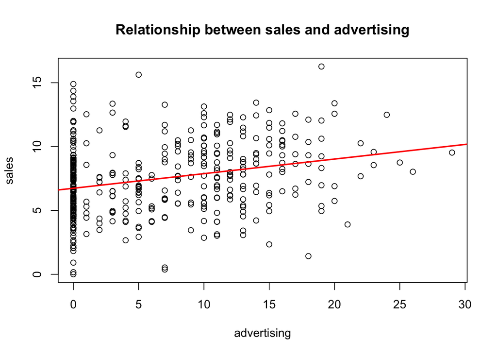

```r
model_6 = lm(Sales ~ Advertising, data = Carseats)
plot(Carseats$Advertising, Carseats$Sales, xlab="advertising", ylab="sales", main="Relationship between sales and advertising")

abline(model_6,col = "red",lwd = 2)
```

```r
summary(model_6)
```

```
##
## Call:
## lm(formula = Sales ~ Advertising, data = Carseats)
##
## Residuals:
##     Min      1Q  Median      3Q     Max
## -7.3770 -1.9634 -0.1037  1.7222  8.3208
##
## Coefficients:
##             Estimate Std. Error t value Pr(>|t|)
## (Intercept)   6.7370     0.1925  35.007  < 2e-16 ***
## Advertising   0.1144     0.0205   5.583 4.38e-08 ***
## ---
## Signif. codes:  0 '***' 0.001 '**' 0.01 '*' 0.05 '.' 0.1 ' ' 1
##
## Residual standard error: 2.723 on 398 degrees of freedom
## Multiple R-squared:  0.07263,    Adjusted R-squared:  0.0703
## F-statistic: 31.17 on 1 and 398 DF,  p-value: 4.378e-08
```

#### (b) Fit a multiple regression model to predict the response using all of the predictors. Describe your results. For which predictors can we reject the null hypothesis $H_0 : β_j = 0$?

##### b-1. Boston data set

```r
library(ISLR2)
data(Boston)
```

```r
multi_model_1 = lm(crim ~ ., data=Boston)
summary(multi_model_1)
```

```
##
## Call:
## lm(formula = crim ~ ., data = Boston)
##
## Residuals:
##    Min     1Q Median     3Q    Max
## -8.534 -2.248 -0.348  1.087 73.923
##
## Coefficients:
##               Estimate Std. Error t value Pr(>|t|)
## (Intercept) 13.7783938  7.0818258   1.946 0.052271 .
## zn           0.0457100  0.0187903   2.433 0.015344 *
## indus       -0.0583501  0.0836351  -0.698 0.485709
## chas        -0.8253776  1.1833963  -0.697 0.485841
## nox         -9.9575865  5.2898242  -1.882 0.060370 .
## rm           0.6289107  0.6070924   1.036 0.300738
## age         -0.0008483  0.0179482  -0.047 0.962323
## dis         -1.0122467  0.2824676  -3.584 0.000373 ***
## rad          0.6124653  0.0875358   6.997 8.59e-12 ***
## tax         -0.0037756  0.0051723  -0.730 0.465757
## ptratio     -0.3040728  0.1863598  -1.632 0.103393
## lstat        0.1388006  0.0757213   1.833 0.067398 .
## medv        -0.2200564  0.0598240  -3.678 0.000261 ***
## ---
## Signif. codes:  0 '***' 0.001 '**' 0.01 '*' 0.05 '.' 0.1 ' ' 1
##
## Residual standard error: 6.46 on 493 degrees of freedom
## Multiple R-squared:  0.4493, Adjusted R-squared:  0.4359
## F-statistic: 33.52 on 12 and 493 DF,  p-value: < 2.2e-16
```

predictors(4) = [zn, dis, rad, medv] can reject the null hypothesis $H_0 : β_j = 0$ because of p-value lower than 0.05. In Boston dataset, multiple regression isn’t appropriate. because R-squared and Adjusted R-squared values have lower than 0.5.  
#################.  
R-squared : 0.4493  
Adjusted R-squared : 0.4359 #################.

##### b-2. Auto data set

```r
library(ISLR2)
data(Auto)
```

```r
#using all predictors accept name
multi_model_2 = lm(mpg ~. -name, data = Auto)
summary(multi_model_2)
```

```
##
## Call:
## lm(formula = mpg ~ . - name, data = Auto)
##
## Residuals:
##     Min      1Q  Median      3Q     Max
## -9.5903 -2.1565 -0.1169  1.8690 13.0604
##
## Coefficients:
##                Estimate Std. Error t value Pr(>|t|)
## (Intercept)  -17.218435   4.644294  -3.707  0.00024 ***
## cylinders     -0.493376   0.323282  -1.526  0.12780
## displacement   0.019896   0.007515   2.647  0.00844 **
## horsepower    -0.016951   0.013787  -1.230  0.21963
## weight        -0.006474   0.000652  -9.929  < 2e-16 ***
## acceleration   0.080576   0.098845   0.815  0.41548
## year           0.750773   0.050973  14.729  < 2e-16 ***
## origin         1.426141   0.278136   5.127 4.67e-07 ***
## ---
## Signif. codes:  0 '***' 0.001 '**' 0.01 '*' 0.05 '.' 0.1 ' ' 1
##
## Residual standard error: 3.328 on 384 degrees of freedom
## Multiple R-squared:  0.8215, Adjusted R-squared:  0.8182
## F-statistic: 252.4 on 7 and 384 DF,  p-value: < 2.2e-16
```

predictors(4) = [displacement, weight, year, origin] can reject the null hypothesis $H_0 : β_j = 0$ because of p-value lower than 0.05. In Auto dataset, multiple regression model is appropriate. because R-squared and Adjusted R-squared values have higher than 0.5.  
*****************  
R-squared : 0.8215  
Adjusted R-squared : 0.8182  
*****************

##### b-3. Carseats data set

```r
library(ISLR2)
data(Carseats)
```

```r
multi_model_3 = lm(Sales ~. , data = Carseats)
summary(multi_model_3)
```

```
##
## Call:
## lm(formula = Sales ~ ., data = Carseats)
##
## Residuals:
##     Min      1Q  Median      3Q     Max
## -2.8692 -0.6908  0.0211  0.6636  3.4115
##
## Coefficients:
##                   Estimate Std. Error t value Pr(>|t|)
## (Intercept)      5.6606231  0.6034487   9.380  < 2e-16 ***
## CompPrice        0.0928153  0.0041477  22.378  < 2e-16 ***
## Income           0.0158028  0.0018451   8.565 2.58e-16 ***
## Advertising      0.1230951  0.0111237  11.066  < 2e-16 ***
## Population       0.0002079  0.0003705   0.561    0.575
## Price           -0.0953579  0.0026711 -35.700  < 2e-16 ***
## ShelveLocGood    4.8501827  0.1531100  31.678  < 2e-16 ***
## ShelveLocMedium  1.9567148  0.1261056  15.516  < 2e-16 ***
## Age             -0.0460452  0.0031817 -14.472  < 2e-16 ***
## Education       -0.0211018  0.0197205  -1.070    0.285
## UrbanYes         0.1228864  0.1129761   1.088    0.277
## USYes           -0.1840928  0.1498423  -1.229    0.220
## ---
## Signif. codes:  0 '***' 0.001 '**' 0.01 '*' 0.05 '.' 0.1 ' ' 1
##
## Residual standard error: 1.019 on 388 degrees of freedom
## Multiple R-squared:  0.8734, Adjusted R-squared:  0.8698
## F-statistic: 243.4 on 11 and 388 DF,  p-value: < 2.2e-16
```

#### (c) How do your results from (a) compare to your results from (b)? Create a plot displaying the univariate regression coefficients from (a) on the x-axis, and the multiple regression coefficients from (b) on the y-axis. That is, each predictor is displayed as a single point in the plot. Its coefficient in a simple linear regression model is shown on the x-axis, and its coefficient estimate in the multiple linear regression model is shown on the y-axis.

##### c-1. Boston data set

```r
m1 = lm(crim ~ zn, data=Boston)
m2 = lm(crim ~ indus, data=Boston)
m3 = lm(crim ~ chas, data=Boston)
m4 = lm(crim ~ nox, data=Boston)
m5 =lm(crim ~ rm, data=Boston)
m6 =lm(crim ~ age, data=Boston)
m7 =lm(crim ~ dis, data=Boston)
m8 =lm(crim ~ rad, data=Boston)
m9 =lm(crim ~ tax, data=Boston)
m10 =lm(crim ~ ptratio, data=Boston)
m11 =lm(crim ~ lstat, data=Boston)
m12 =lm(crim ~ medv, data=Boston)

simple_coefficients_boston = c(
  m1$coefficients[2], m2$coefficients[2],
  m3$coefficients[2], m4$coefficients[2],
  m5$coefficients[2], m6$coefficients[2],
  m7$coefficients[2], m8$coefficients[2],
  m9$coefficients[2], m10$coefficients[2],
  m11$coefficients[2], m12$coefficients[2]
)
multi_coefficients_boston = multi_model_1$coefficients
multi_coefficients_boston = multi_coefficients_boston[-1]
```

```r
simple_coefficients_boston
```

```
##          zn       indus        chas         nox          rm         age
## -0.07393498  0.50977633 -1.89277655 31.24853120 -2.68405122  0.10778623
##         dis         rad         tax     ptratio       lstat        medv
## -1.55090168  0.61791093  0.02974225  1.15198279  0.54880478 -0.36315992
```

```r
multi_coefficients_boston
```

```
##            zn         indus          chas           nox            rm
##  0.0457100386 -0.0583501107 -0.8253775522 -9.9575865471  0.6289106622
##           age           dis           rad           tax       ptratio
## -0.0008482791 -1.0122467382  0.6124653115 -0.0037756465 -0.3040727572
##         lstat          medv
##  0.1388005968 -0.2200563590
```

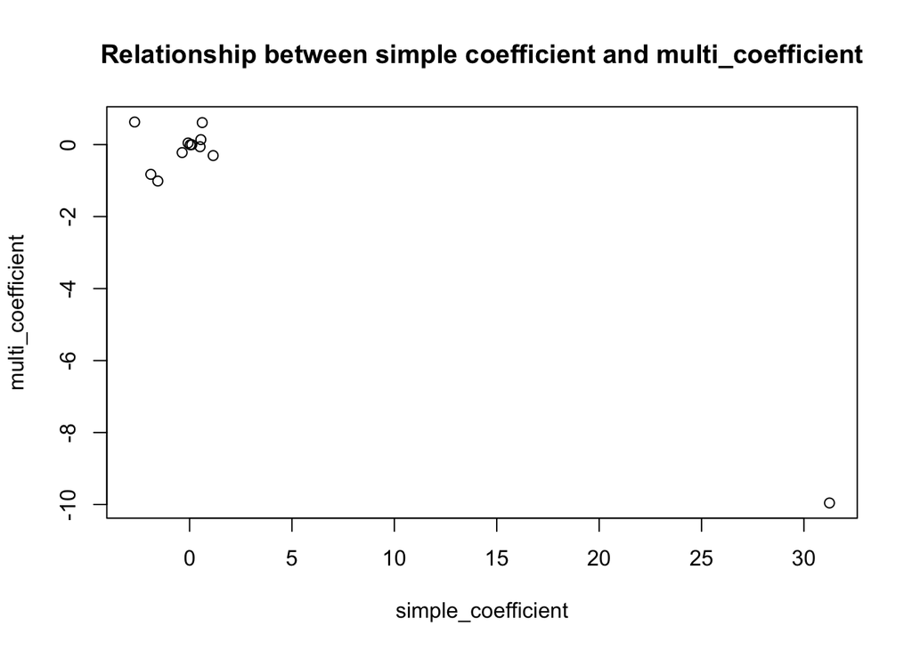

```r
simple_coefficients_boston = as.numeric(simple_coefficients_boston)
multi_coefficients_boston = as.numeric(multi_coefficients_boston)
plot(simple_coefficients_boston, multi_coefficients_boston, xlab="simple_coefficient", ylab="multi_coefficient", main="Relationship between simple coefficient and multi_coefficient")
```

##### c-2. Auto data set

```r
m1 = lm(mpg ~ cylinders, data=Auto)
m2 = lm(mpg ~ displacement, data=Auto)
m3 = lm(mpg ~ horsepower, data=Auto)
m4 = lm(mpg ~ weight, data=Auto)
m5 = lm(mpg ~ acceleration, data=Auto)
m6 = lm(mpg ~ year, data=Auto)
m7 = lm(mpg ~ origin, data=Auto)


simple_coefficients_Auto = c(
  m1$coefficients[2], m2$coefficients[2],
  m3$coefficients[2], m4$coefficients[2],
  m5$coefficients[2], m6$coefficients[2],
  m7$coefficients[2]
)

multi_model_auto = lm(mpg ~ . -name, data=Auto)
multi_coefficients_Auto = multi_model_auto$coefficients
multi_coefficients_Auto = multi_coefficients_Auto[-1]
```

```r
simple_coefficients_Auto
```

```
##    cylinders displacement   horsepower       weight acceleration         year
## -3.558078368 -0.060051428 -0.157844733 -0.007647343  1.197624188  1.230035463
##       origin
##  5.476547480
```

```r
multi_coefficients_Auto
```

```
##    cylinders displacement   horsepower       weight acceleration         year
## -0.493376319  0.019895644 -0.016951144 -0.006474043  0.080575838  0.750772678
##       origin
##  1.426140495
```

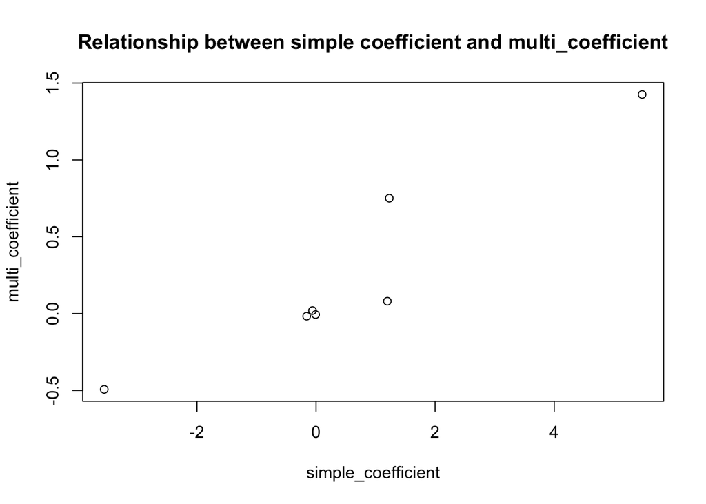

```r
simple_coefficients_Auto = as.numeric(simple_coefficients_Auto)
multi_coefficients_Auto = as.numeric(multi_coefficients_Auto)
plot(simple_coefficients_Auto, multi_coefficients_Auto, xlab="simple_coefficient", ylab="multi_coefficient", main="Relationship between simple coefficient and multi_coefficient")
```

##### c-3. Carseats data set

```r
n1 = lm(Sales ~ CompPrice, data=Carseats)
n2 = lm(Sales ~ Income, data=Carseats)
n3 = lm(Sales ~ Advertising, data=Carseats)
n4 = lm(Sales ~ Population, data=Carseats)
n5 = lm(Sales ~ Price, data=Carseats)
n7 = lm(Sales ~ Age, data=Carseats)
n8 = lm(Sales ~ Education, data=Carseats)
n9 = lm(Sales ~ Urban, data=Carseats)
n10 = lm(Sales ~ US, data=Carseats)


simple_coefficients_Car = c(
  n1$coefficients[2], n2$coefficients[2],
  n3$coefficients[2], n4$coefficients[2],
  n5$coefficients[2],
  n7$coefficients[2], n8$coefficients[2],
  n9$coefficients[2], n10$coefficients[2]

)

multi_model_car = lm(Sales ~. -ShelveLoc, data=Carseats)
multi_coefficients_Car = multi_model_car$coefficients
multi_coefficients_Car = multi_coefficients_Car[-1]
```

```r
simple_coefficients_Car
```

```
##     CompPrice        Income   Advertising    Population         Price
##  0.0118012044  0.0153336128  0.1144475911  0.0009671551 -0.0530730185
##           Age     Education      UrbanYes         USYes
## -0.0404112022 -0.0559916058 -0.0953678327  1.0438710558
```

```r
multi_coefficients_Car
```

```
##     CompPrice        Income   Advertising    Population         Price
##  0.0942544671  0.0130501085  0.1369398910 -0.0002007219 -0.0924395081
##           Age     Education      UrbanYes         USYes
## -0.0447919380 -0.0423034309 -0.1559035988 -0.1062926485
```

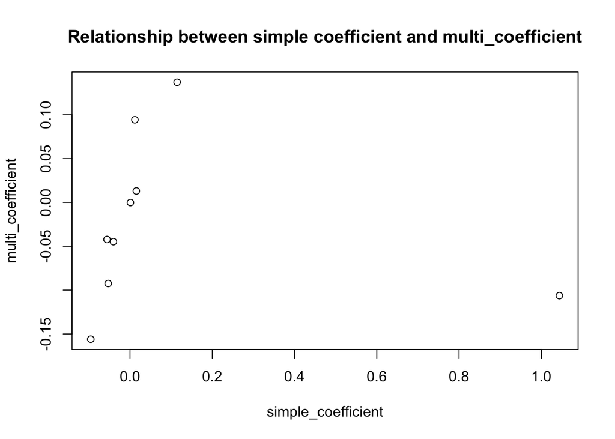

```r
simple_coefficients_Car = as.numeric(simple_coefficients_Car)
multi_coefficients_Car = as.numeric(multi_coefficients_Car)
plot(simple_coefficients_Car, multi_coefficients_Car, xlab="simple_coefficient", ylab="multi_coefficient", main="Relationship between simple coefficient and multi_coefficient")
```

#### (d) Is there evidence of non-linear association between any of the predictors and the response? To answer this question, for each predictor X, fit a model of the form

$$Y=B_0 + B_1X + B_2X^2 + B_3X^3 +
\epsilon$$
##### d-1. Boston data set

```r
m = lm(crim ~ poly(zn,degree=3), data=Boston)
summary(m)
```

```
##
## Call:
## lm(formula = crim ~ poly(zn, degree = 3), data = Boston)
##
## Residuals:
##    Min     1Q Median     3Q    Max
## -4.821 -4.614 -1.294  0.473 84.130
##
## Coefficients:
##                       Estimate Std. Error t value Pr(>|t|)
## (Intercept)             3.6135     0.3722   9.709  < 2e-16 ***
## poly(zn, degree = 3)1 -38.7498     8.3722  -4.628  4.7e-06 ***
## poly(zn, degree = 3)2  23.9398     8.3722   2.859  0.00442 **
## poly(zn, degree = 3)3 -10.0719     8.3722  -1.203  0.22954
## ---
## Signif. codes:  0 '***' 0.001 '**' 0.01 '*' 0.05 '.' 0.1 ' ' 1
##
## Residual standard error: 8.372 on 502 degrees of freedom
## Multiple R-squared:  0.05824,    Adjusted R-squared:  0.05261
## F-statistic: 10.35 on 3 and 502 DF,  p-value: 1.281e-06
```

```r
m = lm(crim ~ poly(indus,degree=3), data=Boston)
summary(m)
```

```
##
## Call:
## lm(formula = crim ~ poly(indus, degree = 3), data = Boston)
##
## Residuals:
##    Min     1Q Median     3Q    Max
## -8.278 -2.514  0.054  0.764 79.713
##
## Coefficients:
##                          Estimate Std. Error t value Pr(>|t|)
## (Intercept)                 3.614      0.330  10.950  < 2e-16 ***
## poly(indus, degree = 3)1   78.591      7.423  10.587  < 2e-16 ***
## poly(indus, degree = 3)2  -24.395      7.423  -3.286  0.00109 **
## poly(indus, degree = 3)3  -54.130      7.423  -7.292  1.2e-12 ***
## ---
## Signif. codes:  0 '***' 0.001 '**' 0.01 '*' 0.05 '.' 0.1 ' ' 1
##
## Residual standard error: 7.423 on 502 degrees of freedom
## Multiple R-squared:  0.2597, Adjusted R-squared:  0.2552
## F-statistic: 58.69 on 3 and 502 DF,  p-value: < 2.2e-16
```

```r
m = lm(crim ~ poly(nox,degree=3), data=Boston)
summary(m)
```

```
##
## Call:
## lm(formula = crim ~ poly(nox, degree = 3), data = Boston)
##
## Residuals:
##    Min     1Q Median     3Q    Max
## -9.110 -2.068 -0.255  0.739 78.302
##
## Coefficients:
##                        Estimate Std. Error t value Pr(>|t|)
## (Intercept)              3.6135     0.3216  11.237  < 2e-16 ***
## poly(nox, degree = 3)1  81.3720     7.2336  11.249  < 2e-16 ***
## poly(nox, degree = 3)2 -28.8286     7.2336  -3.985 7.74e-05 ***
## poly(nox, degree = 3)3 -60.3619     7.2336  -8.345 6.96e-16 ***
## ---
## Signif. codes:  0 '***' 0.001 '**' 0.01 '*' 0.05 '.' 0.1 ' ' 1
##
## Residual standard error: 7.234 on 502 degrees of freedom
## Multiple R-squared:  0.297,  Adjusted R-squared:  0.2928
## F-statistic: 70.69 on 3 and 502 DF,  p-value: < 2.2e-16
```

```r
m = lm(crim ~ poly(rm,degree=3), data=Boston)
summary(m)
```

```
##
## Call:
## lm(formula = crim ~ poly(rm, degree = 3), data = Boston)
##
## Residuals:
##     Min      1Q  Median      3Q     Max
## -18.485  -3.468  -2.221  -0.015  87.219
##
## Coefficients:
##                       Estimate Std. Error t value Pr(>|t|)
## (Intercept)             3.6135     0.3703   9.758  < 2e-16 ***
## poly(rm, degree = 3)1 -42.3794     8.3297  -5.088 5.13e-07 ***
## poly(rm, degree = 3)2  26.5768     8.3297   3.191  0.00151 **
## poly(rm, degree = 3)3  -5.5103     8.3297  -0.662  0.50858
## ---
## Signif. codes:  0 '***' 0.001 '**' 0.01 '*' 0.05 '.' 0.1 ' ' 1
##
## Residual standard error: 8.33 on 502 degrees of freedom
## Multiple R-squared:  0.06779,    Adjusted R-squared:  0.06222
## F-statistic: 12.17 on 3 and 502 DF,  p-value: 1.067e-07
```

```r
m = lm(crim ~ poly(age,degree=3), data=Boston)
summary(m)
```

```
##
## Call:
## lm(formula = crim ~ poly(age, degree = 3), data = Boston)
##
## Residuals:
##    Min     1Q Median     3Q    Max
## -9.762 -2.673 -0.516  0.019 82.842
##
## Coefficients:
##                        Estimate Std. Error t value Pr(>|t|)
## (Intercept)              3.6135     0.3485  10.368  < 2e-16 ***
## poly(age, degree = 3)1  68.1820     7.8397   8.697  < 2e-16 ***
## poly(age, degree = 3)2  37.4845     7.8397   4.781 2.29e-06 ***
## poly(age, degree = 3)3  21.3532     7.8397   2.724  0.00668 **
## ---
## Signif. codes:  0 '***' 0.001 '**' 0.01 '*' 0.05 '.' 0.1 ' ' 1
##
## Residual standard error: 7.84 on 502 degrees of freedom
## Multiple R-squared:  0.1742, Adjusted R-squared:  0.1693
## F-statistic: 35.31 on 3 and 502 DF,  p-value: < 2.2e-16
```

```r
m = lm(crim ~ poly(dis,degree=3), data=Boston)
summary(m)
```

```
##
## Call:
## lm(formula = crim ~ poly(dis, degree = 3), data = Boston)
##
## Residuals:
##     Min      1Q  Median      3Q     Max
## -10.757  -2.588   0.031   1.267  76.378
##
## Coefficients:
##                        Estimate Std. Error t value Pr(>|t|)
## (Intercept)              3.6135     0.3259  11.087  < 2e-16 ***
## poly(dis, degree = 3)1 -73.3886     7.3315 -10.010  < 2e-16 ***
## poly(dis, degree = 3)2  56.3730     7.3315   7.689 7.87e-14 ***
## poly(dis, degree = 3)3 -42.6219     7.3315  -5.814 1.09e-08 ***
## ---
## Signif. codes:  0 '***' 0.001 '**' 0.01 '*' 0.05 '.' 0.1 ' ' 1
##
## Residual standard error: 7.331 on 502 degrees of freedom
## Multiple R-squared:  0.2778, Adjusted R-squared:  0.2735
## F-statistic: 64.37 on 3 and 502 DF,  p-value: < 2.2e-16
```

```r
m = lm(crim ~ poly(rad,degree=3), data=Boston)
summary(m)
```

```
##
## Call:
## lm(formula = crim ~ poly(rad, degree = 3), data = Boston)
##
## Residuals:
##     Min      1Q  Median      3Q     Max
## -10.381  -0.412  -0.269   0.179  76.217
##
## Coefficients:
##                        Estimate Std. Error t value Pr(>|t|)
## (Intercept)              3.6135     0.2971  12.164  < 2e-16 ***
## poly(rad, degree = 3)1 120.9074     6.6824  18.093  < 2e-16 ***
## poly(rad, degree = 3)2  17.4923     6.6824   2.618  0.00912 **
## poly(rad, degree = 3)3   4.6985     6.6824   0.703  0.48231
## ---
## Signif. codes:  0 '***' 0.001 '**' 0.01 '*' 0.05 '.' 0.1 ' ' 1
##
## Residual standard error: 6.682 on 502 degrees of freedom
## Multiple R-squared:    0.4,  Adjusted R-squared:  0.3965
## F-statistic: 111.6 on 3 and 502 DF,  p-value: < 2.2e-16
```

```r
m = lm(crim ~ poly(tax,degree=3), data=Boston)
summary(m)
```

```
##
## Call:
## lm(formula = crim ~ poly(tax, degree = 3), data = Boston)
##
## Residuals:
##     Min      1Q  Median      3Q     Max
## -13.273  -1.389   0.046   0.536  76.950
##
## Coefficients:
##                        Estimate Std. Error t value Pr(>|t|)
## (Intercept)              3.6135     0.3047  11.860  < 2e-16 ***
## poly(tax, degree = 3)1 112.6458     6.8537  16.436  < 2e-16 ***
## poly(tax, degree = 3)2  32.0873     6.8537   4.682 3.67e-06 ***
## poly(tax, degree = 3)3  -7.9968     6.8537  -1.167    0.244
## ---
## Signif. codes:  0 '***' 0.001 '**' 0.01 '*' 0.05 '.' 0.1 ' ' 1
##
## Residual standard error: 6.854 on 502 degrees of freedom
## Multiple R-squared:  0.3689, Adjusted R-squared:  0.3651
## F-statistic:  97.8 on 3 and 502 DF,  p-value: < 2.2e-16
```

```r
m = lm(crim ~ poly(ptratio,degree=3), data=Boston)
summary(m)
```

```
##
## Call:
## lm(formula = crim ~ poly(ptratio, degree = 3), data = Boston)
##
## Residuals:
##    Min     1Q Median     3Q    Max
## -6.833 -4.146 -1.655  1.408 82.697
##
## Coefficients:
##                            Estimate Std. Error t value Pr(>|t|)
## (Intercept)                   3.614      0.361  10.008  < 2e-16 ***
## poly(ptratio, degree = 3)1   56.045      8.122   6.901 1.57e-11 ***
## poly(ptratio, degree = 3)2   24.775      8.122   3.050  0.00241 **
## poly(ptratio, degree = 3)3  -22.280      8.122  -2.743  0.00630 **
## ---
## Signif. codes:  0 '***' 0.001 '**' 0.01 '*' 0.05 '.' 0.1 ' ' 1
##
## Residual standard error: 8.122 on 502 degrees of freedom
## Multiple R-squared:  0.1138, Adjusted R-squared:  0.1085
## F-statistic: 21.48 on 3 and 502 DF,  p-value: 4.171e-13
```

##### d-2. Auto data set

```r
m = lm(mpg ~ poly(cylinders,degree=3), data=Auto)
summary(m)
```

```
##
## Call:
## lm(formula = mpg ~ poly(cylinders, degree = 3), data = Auto)
##
## Residuals:
##      Min       1Q   Median       3Q      Max
## -11.2869  -2.9058  -0.9627   2.3403  18.0218
##
## Coefficients:
##                              Estimate Std. Error t value Pr(>|t|)
## (Intercept)                    23.446      0.237  98.919  < 2e-16 ***
## poly(cylinders, degree = 3)1 -120.013      4.693 -25.574  < 2e-16 ***
## poly(cylinders, degree = 3)2    8.113      4.693   1.729   0.0846 .
## poly(cylinders, degree = 3)3   28.379      4.693   6.047 3.46e-09 ***
## ---
## Signif. codes:  0 '***' 0.001 '**' 0.01 '*' 0.05 '.' 0.1 ' ' 1
##
## Residual standard error: 4.693 on 388 degrees of freedom
## Multiple R-squared:  0.6413, Adjusted R-squared:  0.6385
## F-statistic: 231.2 on 3 and 388 DF,  p-value: < 2.2e-16
```

```r
n = lm(mpg ~ cylinders, data=Auto)
summary(n)$r.squared
```

```
## [1] 0.604689
```

```r
m = lm(mpg ~ poly(displacement,degree=3), data=Auto)
summary(m)
```

```
##
## Call:
## lm(formula = mpg ~ poly(displacement, degree = 3), data = Auto)
##
## Residuals:
##      Min       1Q   Median       3Q      Max
## -15.6791  -2.3900  -0.2987   2.1156  20.4528
##
## Coefficients:
##                                  Estimate Std. Error t value Pr(>|t|)
## (Intercept)                       23.4459     0.2205 106.350  < 2e-16 ***
## poly(displacement, degree = 3)1 -124.2585     4.3649 -28.468  < 2e-16 ***
## poly(displacement, degree = 3)2   31.0895     4.3649   7.123 5.18e-12 ***
## poly(displacement, degree = 3)3   -4.4655     4.3649  -1.023    0.307
## ---
## Signif. codes:  0 '***' 0.001 '**' 0.01 '*' 0.05 '.' 0.1 ' ' 1
##
## Residual standard error: 4.365 on 388 degrees of freedom
## Multiple R-squared:  0.6896, Adjusted R-squared:  0.6872
## F-statistic: 287.4 on 3 and 388 DF,  p-value: < 2.2e-16
```

```r
n = lm(mpg ~ displacement, data=Auto)
summary(n)$r.squared
```

```
## [1] 0.6482294
```

```r
m = lm(mpg ~ poly(horsepower,degree=3), data=Auto)
summary(m)
```

```
##
## Call:
## lm(formula = mpg ~ poly(horsepower, degree = 3), data = Auto)
##
## Residuals:
##      Min       1Q   Median       3Q      Max
## -14.7039  -2.4491  -0.1519   2.2035  15.8159
##
## Coefficients:
##                               Estimate Std. Error t value Pr(>|t|)
## (Intercept)                     23.446      0.221 106.105   <2e-16 ***
## poly(horsepower, degree = 3)1 -120.138      4.375 -27.460   <2e-16 ***
## poly(horsepower, degree = 3)2   44.090      4.375  10.078   <2e-16 ***
## poly(horsepower, degree = 3)3   -3.949      4.375  -0.903    0.367
## ---
## Signif. codes:  0 '***' 0.001 '**' 0.01 '*' 0.05 '.' 0.1 ' ' 1
##
## Residual standard error: 4.375 on 388 degrees of freedom
## Multiple R-squared:  0.6882, Adjusted R-squared:  0.6858
## F-statistic: 285.5 on 3 and 388 DF,  p-value: < 2.2e-16
```

```r
n = lm(mpg ~ horsepower, data=Auto)
summary(n)$r.squared
```

```
## [1] 0.6059483
```

```r
m = lm(mpg ~ poly(weight,degree=3), data=Auto)
summary(m)
```

```
##
## Call:
## lm(formula = mpg ~ poly(weight, degree = 3), data = Auto)
##
## Residuals:
##      Min       1Q   Median       3Q      Max
## -12.6259  -2.7080  -0.3552   1.8385  16.0816
##
## Coefficients:
##                            Estimate Std. Error t value Pr(>|t|)
## (Intercept)                 23.4459     0.2112 111.008  < 2e-16 ***
## poly(weight, degree = 3)1 -128.4436     4.1817 -30.716  < 2e-16 ***
## poly(weight, degree = 3)2   23.1589     4.1817   5.538 5.65e-08 ***
## poly(weight, degree = 3)3    0.2204     4.1817   0.053    0.958
## ---
## Signif. codes:  0 '***' 0.001 '**' 0.01 '*' 0.05 '.' 0.1 ' ' 1
##
## Residual standard error: 4.182 on 388 degrees of freedom
## Multiple R-squared:  0.7151, Adjusted R-squared:  0.7129
## F-statistic: 324.7 on 3 and 388 DF,  p-value: < 2.2e-16
```

```r
n = lm(mpg ~ weight, data=Auto)
summary(n)$r.squared
```

```
## [1] 0.6926304
```

```r
m = lm(mpg ~ poly(acceleration,degree=3), data=Auto)
summary(m)
```

```
##
## Call:
## lm(formula = mpg ~ poly(acceleration, degree = 3), data = Auto)
##
## Residuals:
##      Min       1Q   Median       3Q      Max
## -17.7828  -5.5661  -0.8348   4.7540  22.7574
##
## Coefficients:
##                                 Estimate Std. Error t value Pr(>|t|)
## (Intercept)                      23.4459     0.3549  66.055  < 2e-16 ***
## poly(acceleration, degree = 3)1  65.3340     7.0276   9.297  < 2e-16 ***
## poly(acceleration, degree = 3)2 -18.7482     7.0276  -2.668  0.00795 **
## poly(acceleration, degree = 3)3   6.0643     7.0276   0.863  0.38871
## ---
## Signif. codes:  0 '***' 0.001 '**' 0.01 '*' 0.05 '.' 0.1 ' ' 1
##
## Residual standard error: 7.028 on 388 degrees of freedom
## Multiple R-squared:  0.1955, Adjusted R-squared:  0.1893
## F-statistic: 31.43 on 3 and 388 DF,  p-value: < 2.2e-16
```

```r
n = lm(mpg ~ acceleration, data=Auto)
summary(n)$r.squared
```

```
## [1] 0.1792071
```

```r
m = lm(mpg ~ poly(year,degree=3), data=Auto)
summary(m)
```

```
##
## Call:
## lm(formula = mpg ~ poly(year, degree = 3), data = Auto)
##
## Residuals:
##      Min       1Q   Median       3Q      Max
## -13.2690  -5.0507  -0.8684   4.8333  17.9470
##
## Coefficients:
##                         Estimate Std. Error t value Pr(>|t|)
## (Intercept)              23.4459     0.3144  74.568  < 2e-16 ***
## poly(year, degree = 3)1  89.5972     6.2253  14.392  < 2e-16 ***
## poly(year, degree = 3)2  26.9524     6.2253   4.330  1.9e-05 ***
## poly(year, degree = 3)3  -5.3209     6.2253  -0.855    0.393
## ---
## Signif. codes:  0 '***' 0.001 '**' 0.01 '*' 0.05 '.' 0.1 ' ' 1
##
## Residual standard error: 6.225 on 388 degrees of freedom
## Multiple R-squared:  0.3687, Adjusted R-squared:  0.3638
## F-statistic: 75.54 on 3 and 388 DF,  p-value: < 2.2e-16
```

```r
n = lm(mpg ~ year, data=Auto)
summary(n)$r.squared
```

```
## [1] 0.3370278
```

##### d-3. Carseats data set

```r
m = lm(Sales ~ poly(CompPrice,degree=3), data=Carseats)
summary(m)
```

```
##
## Call:
## lm(formula = Sales ~ poly(CompPrice, degree = 3), data = Carseats)
##
## Residuals:
##     Min      1Q  Median      3Q     Max
## -7.7428 -2.0330 -0.0746  1.6843  8.4670
##
## Coefficients:
##                              Estimate Std. Error t value Pr(>|t|)
## (Intercept)                     7.496      0.141  53.174   <2e-16 ***
## poly(CompPrice, degree = 3)1    3.615      2.820   1.282    0.201
## poly(CompPrice, degree = 3)2    3.922      2.820   1.391    0.165
## poly(CompPrice, degree = 3)3   -2.397      2.820  -0.850    0.396
## ---
## Signif. codes:  0 '***' 0.001 '**' 0.01 '*' 0.05 '.' 0.1 ' ' 1
##
## Residual standard error: 2.82 on 396 degrees of freedom
## Multiple R-squared:  0.01075,    Adjusted R-squared:  0.003252
## F-statistic: 1.434 on 3 and 396 DF,  p-value: 0.2324
```

```r
m = lm(Sales ~ poly(Income,degree=3), data=Carseats)
summary(m)
```

```
##
## Call:
## lm(formula = Sales ~ poly(Income, degree = 3), data = Carseats)
##
## Residuals:
##     Min      1Q  Median      3Q     Max
## -7.3307 -1.9700 -0.1845  1.7124  8.8275
##
## Coefficients:
##                           Estimate Std. Error t value Pr(>|t|)
## (Intercept)                 7.4963     0.1400  53.541  < 2e-16 ***
## poly(Income, degree = 3)1   8.5718     2.8002   3.061  0.00236 **
## poly(Income, degree = 3)2  -1.9009     2.8002  -0.679  0.49764
## poly(Income, degree = 3)3  -0.2259     2.8002  -0.081  0.93574
## ---
## Signif. codes:  0 '***' 0.001 '**' 0.01 '*' 0.05 '.' 0.1 ' ' 1
##
## Residual standard error: 2.8 on 396 degrees of freedom
## Multiple R-squared:  0.02424,    Adjusted R-squared:  0.01685
## F-statistic: 3.279 on 3 and 396 DF,  p-value: 0.02101
```

```r
m = lm(Sales ~ poly(Advertising,degree=3), data=Carseats)
summary(m)
```

```
##
## Call:
## lm(formula = Sales ~ poly(Advertising, degree = 3), data = Carseats)
##
## Residuals:
##    Min     1Q Median     3Q    Max
## -7.585 -1.956 -0.121  1.676  8.531
##
## Coefficients:
##                                Estimate Std. Error t value Pr(>|t|)
## (Intercept)                      7.4963     0.1363  55.000  < 2e-16 ***
## poly(Advertising, degree = 3)1  15.2033     2.7260   5.577 4.53e-08 ***
## poly(Advertising, degree = 3)2   0.3261     2.7260   0.120    0.905
## poly(Advertising, degree = 3)3  -2.8993     2.7260  -1.064    0.288
## ---
## Signif. codes:  0 '***' 0.001 '**' 0.01 '*' 0.05 '.' 0.1 ' ' 1
##
## Residual standard error: 2.726 on 396 degrees of freedom
## Multiple R-squared:  0.07531,    Adjusted R-squared:  0.0683
## F-statistic: 10.75 on 3 and 396 DF,  p-value: 8.322e-07
```

```r
m = lm(Sales ~ poly(Population,degree=3), data=Carseats)
summary(m)
```

```
##
## Call:
## lm(formula = Sales ~ poly(Population, degree = 3), data = Carseats)
##
## Residuals:
##     Min      1Q  Median      3Q     Max
## -7.7285 -2.0013 -0.0518  1.7449  8.5792
##
## Coefficients:
##                               Estimate Std. Error t value Pr(>|t|)
## (Intercept)                     7.4963     0.1414  53.000   <2e-16 ***
## poly(Population, degree = 3)1   2.8472     2.8288   1.006    0.315
## poly(Population, degree = 3)2  -1.6934     2.8288  -0.599    0.550
## poly(Population, degree = 3)3  -1.5711     2.8288  -0.555    0.579
## ---
## Signif. codes:  0 '***' 0.001 '**' 0.01 '*' 0.05 '.' 0.1 ' ' 1
##
## Residual standard error: 2.829 on 396 degrees of freedom
## Multiple R-squared:  0.004224,   Adjusted R-squared:  -0.00332
## F-statistic:  0.56 on 3 and 396 DF,  p-value: 0.6417
```

```r
m = lm(Sales ~ poly(Price,degree=3), data=Carseats)
summary(m)
```

```
##
## Call:
## lm(formula = Sales ~ poly(Price, degree = 3), data = Carseats)
##
## Residuals:
##    Min     1Q Median     3Q    Max
## -6.508 -1.866 -0.115  1.621  7.572
##
## Coefficients:
##                          Estimate Std. Error t value Pr(>|t|)
## (Intercept)                7.4963     0.1269  59.090   <2e-16 ***
## poly(Price, degree = 3)1 -25.1004     2.5372  -9.893   <2e-16 ***
## poly(Price, degree = 3)2   0.8757     2.5372   0.345     0.73
## poly(Price, degree = 3)3  -1.4800     2.5372  -0.583     0.56
## ---
## Signif. codes:  0 '***' 0.001 '**' 0.01 '*' 0.05 '.' 0.1 ' ' 1
##
## Residual standard error: 2.537 on 396 degrees of freedom
## Multiple R-squared:  0.1989, Adjusted R-squared:  0.1928
## F-statistic: 32.78 on 3 and 396 DF,  p-value: < 2.2e-16
```

```r
m = lm(Sales ~ poly(Age,degree=3), data=Carseats)
summary(m)
```

```
##
## Call:
## lm(formula = Sales ~ poly(Age, degree = 3), data = Carseats)
##
## Residuals:
##     Min      1Q  Median      3Q     Max
## -7.6426 -2.0234  0.0684  1.7014  8.1503
##
## Coefficients:
##                        Estimate Std. Error t value Pr(>|t|)
## (Intercept)              7.4963     0.1368  54.816  < 2e-16 ***
## poly(Age, degree = 3)1 -13.0771     2.7351  -4.781 2.46e-06 ***
## poly(Age, degree = 3)2  -6.9793     2.7351  -2.552   0.0111 *
## poly(Age, degree = 3)3  -0.3927     2.7351  -0.144   0.8859
## ---
## Signif. codes:  0 '***' 0.001 '**' 0.01 '*' 0.05 '.' 0.1 ' ' 1
##
## Residual standard error: 2.735 on 396 degrees of freedom
## Multiple R-squared:  0.06909,    Adjusted R-squared:  0.06204
## F-statistic: 9.797 on 3 and 396 DF,  p-value: 3.011e-06
```

```r
m = lm(Sales ~ poly(Education,degree=3), data=Carseats)
summary(m)
```

```
##
## Call:
## lm(formula = Sales ~ poly(Education, degree = 3), data = Carseats)
##
## Residuals:
##     Min      1Q  Median      3Q     Max
## -7.4571 -2.0296 -0.0405  1.7992  8.6928
##
## Coefficients:
##                              Estimate Std. Error t value Pr(>|t|)
## (Intercept)                     7.496      0.141  53.183   <2e-16 ***
## poly(Education, degree = 3)1   -2.931      2.819  -1.040    0.299
## poly(Education, degree = 3)2    3.180      2.819   1.128    0.260
## poly(Education, degree = 3)3   -4.059      2.819  -1.440    0.151
## ---
## Signif. codes:  0 '***' 0.001 '**' 0.01 '*' 0.05 '.' 0.1 ' ' 1
##
## Residual standard error: 2.819 on 396 degrees of freedom
## Multiple R-squared:  0.01105,    Adjusted R-squared:  0.003563
## F-statistic: 1.476 on 3 and 396 DF,  p-value: 0.2207
```